# Assignment2

Kelsie Reinaltt

9/6/2018

# 5.2.4

# Question 1.1

```r
filter(flights, arr_delay >= 120)
```

```
## # A tibble: 10,200 x 19
##     year month   day dep_time sched_dep_time dep_delay arr_time
##    <int> <int> <int>    <int>          <int>     <dbl>    <int>
##  1  2013     1     1      811            630       101     1047
##  2  2013     1     1      848           1835       853     1001
##  3  2013     1     1      957            733       144     1056
##  4  2013     1     1     1114            900       134     1447
##  5  2013     1     1     1505           1310       115     1638
##  6  2013     1     1     1525           1340       105     1831
##  7  2013     1     1     1549           1445        64     1912
##  8  2013     1     1     1558           1359       119     1718
##  9  2013     1     1     1732           1630        62     2028
## 10  2013     1     1     1803           1620       103     2008
## # ... with 10,190 more rows, and 12 more variables: sched_arr_time <int>,
## #   arr_delay <dbl>, carrier <chr>, flight <int>, tailnum <chr>,
## #   origin <chr>, dest <chr>, air_time <dbl>, distance <dbl>, hour <dbl>,
## #   minute <dbl>, time_hour <dttm>
```

# Question 1.2

```r
filter(flights, dest %in% c("IAH", "HOU"))
```

```
## # A tibble: 9,313 x 19
##     year month   day dep_time sched_dep_time dep_delay arr_time
##    <int> <int> <int>    <int>          <int>     <dbl>    <int>
##  1  2013     1     1      517            515         2      830
##  2  2013     1     1      533            529         4      850
##  3  2013     1     1      623            627        -4      933
##  4  2013     1     1      728            732        -4     1041
##  5  2013     1     1      739            739         0     1104
##  6  2013     1     1      908            908         0     1228
##  7  2013     1     1     1028           1026         2     1350
##  8  2013     1     1     1044           1045        -1     1352
##  9  2013     1     1     1114            900       134     1447
## 10  2013     1     1     1205           1200         5     1503
## # ... with 9,303 more rows, and 12 more variables: sched_arr_time <int>,
## #   arr_delay <dbl>, carrier <chr>, flight <int>, tailnum <chr>,
## #   origin <chr>, dest <chr>, air_time <dbl>, distance <dbl>, hour <dbl>,
## #   minute <dbl>, time_hour <dttm>
```

# Question 1.3

```r
filter(flights, carrier %in% c("AA", "DL", "UA"))
```

```
## # A tibble: 139,504 x 19
##     year month   day dep_time sched_dep_time dep_delay arr_time
##    <int> <int> <int>    <int>          <int>     <dbl>    <int>
##  1  2013     1     1      517            515         2      830
##  2  2013     1     1      533            529         4      850
##  3  2013     1     1      542            540         2      923
##  4  2013     1     1      554            600        -6      812
##  5  2013     1     1      554            558        -4      740
##  6  2013     1     1      558            600        -2      753
##  7  2013     1     1      558            600        -2      924
##  8  2013     1     1      558            600        -2      923
##  9  2013     1     1      559            600        -1      941
## 10  2013     1     1      559            600        -1      854
## # ... with 139,494 more rows, and 12 more variables: sched_arr_time <int>,
## #   arr_delay <dbl>, carrier <chr>, flight <int>, tailnum <chr>,
## #   origin <chr>, dest <chr>, air_time <dbl>, distance <dbl>, hour <dbl>,
## #   minute <dbl>, time_hour <dttm>
```

# Question 1.4

```r
filter(flights, month >= 7, month <= 9)
```

```
## # A tibble: 86,326 x 19
##     year month   day dep_time sched_dep_time dep_delay arr_time
##    <int> <int> <int>    <int>          <int>     <dbl>    <int>
##  1  2013     7     1        1           2029       212      236
##  2  2013     7     1        2           2359         3      344
##  3  2013     7     1       29           2245       104      151
##  4  2013     7     1       43           2130       193      322
##  5  2013     7     1       44           2150       174      300
##  6  2013     7     1       46           2051       235      304
##  7  2013     7     1       48           2001       287      308
##  8  2013     7     1       58           2155       183      335
##  9  2013     7     1      100           2146       194      327
## 10  2013     7     1      100           2245       135      337
## # ... with 86,316 more rows, and 12 more variables: sched_arr_time <int>,
## #   arr_delay <dbl>, carrier <chr>, flight <int>, tailnum <chr>,
## #   origin <chr>, dest <chr>, air_time <dbl>, distance <dbl>, hour <dbl>,
## #   minute <dbl>, time_hour <dttm>
```

# Question 1.5

```r
filter(flights, dep_delay <= 0, arr_delay > 120)
```

```
## # A tibble: 29 x 19
##     year month   day dep_time sched_dep_time dep_delay arr_time
##    <int> <int> <int>    <int>          <int>     <dbl>    <int>
##  1  2013     1    27     1419           1420        -1     1754
##  2  2013    10     7     1350           1350         0     1736
##  3  2013    10     7     1357           1359        -2     1858
##  4  2013    10    16      657            700        -3     1258
##  5  2013    11     1      658            700        -2     1329
##  6  2013     3    18     1844           1847        -3       39
##  7  2013     4    17     1635           1640        -5     2049
##  8  2013     4    18      558            600        -2     1149
##  9  2013     4    18      655            700        -5     1213
## 10  2013     5    22     1827           1830        -3     2217
## # ... with 19 more rows, and 12 more variables: sched_arr_time <int>,
## #   arr_delay <dbl>, carrier <chr>, flight <int>, tailnum <chr>,
## #   origin <chr>, dest <chr>, air_time <dbl>, distance <dbl>, hour <dbl>,
## #   minute <dbl>, time_hour <dttm>
```

# Question 1.6

```r
filter(flights, dep_delay >= 60, dep_delay - arr_delay > 30)
```

```
## # A tibble: 1,844 x 19
##     year month   day dep_time sched_dep_time dep_delay arr_time
##    <int> <int> <int>    <int>          <int>     <dbl>    <int>
##  1  2013     1     1     2205           1720       285       46
##  2  2013     1     1     2326           2130       116      131
##  3  2013     1     3     1503           1221       162     1803
##  4  2013     1     3     1839           1700        99     2056
##  5  2013     1     3     1850           1745        65     2148
##  6  2013     1     3     1941           1759       102     2246
##  7  2013     1     3     1950           1845        65     2228
##  8  2013     1     3     2015           1915        60     2135
##  9  2013     1     3     2257           2000       177       45
## 10  2013     1     4     1917           1700       137     2135
## # ... with 1,834 more rows, and 12 more variables: sched_arr_time <int>,
## #   arr_delay <dbl>, carrier <chr>, flight <int>, tailnum <chr>,
## #   origin <chr>, dest <chr>, air_time <dbl>, distance <dbl>, hour <dbl>,
## #   minute <dbl>, time_hour <dttm>
```

# Question 1.7

```r
filter(flights, dep_time <= 600 | dep_time == 2400)
```

```
## # A tibble: 9,373 x 19
##     year month   day dep_time sched_dep_time dep_delay arr_time
##    <int> <int> <int>    <int>          <int>     <dbl>    <int>
##  1  2013     1     1      517            515         2      830
##  2  2013     1     1      533            529         4      850
##  3  2013     1     1      542            540         2      923
##  4  2013     1     1      544            545        -1     1004
##  5  2013     1     1      554            600        -6      812
##  6  2013     1     1      554            558        -4      740
##  7  2013     1     1      555            600        -5      913
##  8  2013     1     1      557            600        -3      709
##  9  2013     1     1      557            600        -3      838
## 10  2013     1     1      558            600        -2      753
## # ... with 9,363 more rows, and 12 more variables: sched_arr_time <int>,
## #   arr_delay <dbl>, carrier <chr>, flight <int>, tailnum <chr>,
## #   origin <chr>, dest <chr>, air_time <dbl>, distance <dbl>, hour <dbl>,
## #   minute <dbl>, time_hour <dttm>
```

# Question 2

# Between is a shorter, faster way of testing two inequalities at once: it tests if its first argument is greater than or equal to its second, and less than or equal to its third.

# Question 3

### 8255 flights have missing departure times. 8255 flights have missing departure delays. 8713 flights have missing arrival times. 9430 flights have missing arrival delays. 9430 flights have missing air time.

### The flights with missing data may indicate that the flights in question may have never departed or arrived. The flights that departed but never arrived may have been rerouted. The missing data may also be a result of lost data.

```r
summary(flights)
```

```
##       year          month             day           dep_time
##  Min.   :2013   Min.   : 1.000   Min.   : 1.00   Min.   :   1
##  1st Qu.:2013   1st Qu.: 4.000   1st Qu.: 8.00   1st Qu.: 907
##  Median :2013   Median : 7.000   Median :16.00   Median :1401
##  Mean   :2013   Mean   : 6.549   Mean   :15.71   Mean   :1349
##  3rd Qu.:2013   3rd Qu.:10.000   3rd Qu.:23.00   3rd Qu.:1744
##  Max.   :2013   Max.   :12.000   Max.   :31.00   Max.   :2400
##                                                  NA's   :8255
##  sched_dep_time   dep_delay          arr_time    sched_arr_time
##  Min.   : 106   Min.   : -43.00   Min.   :   1   Min.   :   1
##  1st Qu.: 906   1st Qu.:  -5.00   1st Qu.:1104   1st Qu.:1124
##  Median :1359   Median :  -2.00   Median :1535   Median :1556
##  Mean   :1344   Mean   :  12.64   Mean   :1502   Mean   :1536
##  3rd Qu.:1729   3rd Qu.:  11.00   3rd Qu.:1940   3rd Qu.:1945
##  Max.   :2359   Max.   :1301.00   Max.   :2400   Max.   :2359
##                 NA's   :8255      NA's   :8713
##    arr_delay          carrier              flight       tailnum
##  Min.   : -86.000   Length:336776      Min.   :   1   Length:336776
##  1st Qu.: -17.000   Class :character   1st Qu.: 553   Class :character
##  Median :  -5.000   Mode  :character   Median :1496   Mode  :character
##  Mean   :   6.895                      Mean   :1972
##  3rd Qu.:  14.000                      3rd Qu.:3465
##  Max.   :1272.000                      Max.   :8500
##  NA's   :9430
##     origin              dest              air_time        distance
##  Length:336776      Length:336776      Min.   : 20.0   Min.   :  17
##  Class :character   Class :character   1st Qu.: 82.0   1st Qu.: 502
##  Mode  :character   Mode  :character   Median :129.0   Median : 872
##                                        Mean   :150.7   Mean   :1040
##                                        3rd Qu.:192.0   3rd Qu.:1389
##                                        Max.   :695.0   Max.   :4983
##                                        NA's   :9430
##       hour           minute        time_hour
##  Min.   : 1.00   Min.   : 0.00   Min.   :2013-01-01 05:00:00
##  1st Qu.: 9.00   1st Qu.: 8.00   1st Qu.:2013-04-04 13:00:00
##  Median :13.00   Median :29.00   Median :2013-07-03 10:00:00
##  Mean   :13.18   Mean   :26.23   Mean   :2013-07-03 05:22:54
##  3rd Qu.:17.00   3rd Qu.:44.00   3rd Qu.:2013-10-01 07:00:00
##  Max.   :23.00   Max.   :59.00   Max.   :2013-12-31 23:00:00
##
```

# Question 4

### Anything to the 0th power results in 1. Therefore, NA ^ 0 = 1, so the values is 1 and is not missing.

### NA | TRUE is not missing because the expresion evaluates to TRUE. If the value is TRUE, the value is not missing.

### FALSE & NA is not missing because the expression evaluates to FALSE. If the value is FALSE, then the value is not missing.

### Expressions involving NA will genearlly follow the universal rules and therefore no longer be missing (ex: TRUE|anything = TRUE, FALSE & anything = FALSE). However, there exist cases in which the universal rules have exceptions, such as NA * 0 = NaN. In such cases, the value remains missing, or NA.

# 5.3.1

# Question 1

```r
arrange(flights, desc(is.na(dep_time)), dep_time)
```

```
## # A tibble: 336,776 x 19
##     year month   day dep_time sched_dep_time dep_delay arr_time
##    <int> <int> <int>    <int>          <int>     <dbl>    <int>
##  1  2013     1     1       NA           1630        NA       NA
##  2  2013     1     1       NA           1935        NA       NA
##  3  2013     1     1       NA           1500        NA       NA
##  4  2013     1     1       NA            600        NA       NA
##  5  2013     1     2       NA           1540        NA       NA
##  6  2013     1     2       NA           1620        NA       NA
##  7  2013     1     2       NA           1355        NA       NA
##  8  2013     1     2       NA           1420        NA       NA
##  9  2013     1     2       NA           1321        NA       NA
## 10  2013     1     2       NA           1545        NA       NA
## # ... with 336,766 more rows, and 12 more variables: sched_arr_time <int>,
## #   arr_delay <dbl>, carrier <chr>, flight <int>, tailnum <chr>,
## #   origin <chr>, dest <chr>, air_time <dbl>, distance <dbl>, hour <dbl>,
## #   minute <dbl>, time_hour <dttm>
```

# Question 2

```r
arrange(flights, desc(dep_delay))
```

```
## # A tibble: 336,776 x 19
##     year month   day dep_time sched_dep_time dep_delay arr_time
##    <int> <int> <int>    <int>          <int>     <dbl>    <int>
##  1  2013     1     9      641            900      1301     1242
##  2  2013     6    15     1432           1935      1137     1607
##  3  2013     1    10     1121           1635      1126     1239
##  4  2013     9    20     1139           1845      1014     1457
##  5  2013     7    22      845           1600      1005     1044
##  6  2013     4    10     1100           1900       960     1342
##  7  2013     3    17     2321            810       911      135
##  8  2013     6    27      959           1900       899     1236
##  9  2013     7    22     2257            759       898      121
## 10  2013    12     5      756           1700       896     1058
## # ... with 336,766 more rows, and 12 more variables: sched_arr_time <int>,
## #   arr_delay <dbl>, carrier <chr>, flight <int>, tailnum <chr>,
## #   origin <chr>, dest <chr>, air_time <dbl>, distance <dbl>, hour <dbl>,
## #   minute <dbl>, time_hour <dttm>
```

# Question 3

```r
arrange(flights, air_time)
```

```
## # A tibble: 336,776 x 19
##     year month   day dep_time sched_dep_time dep_delay arr_time
##    <int> <int> <int>    <int>          <int>     <dbl>    <int>
##  1  2013     1    16     1355           1315        40     1442
##  2  2013     4    13      537            527        10      622
##  3  2013    12     6      922            851        31     1021
##  4  2013     2     3     2153           2129        24     2247
##  5  2013     2     5     1303           1315       -12     1342
##  6  2013     2    12     2123           2130        -7     2211
##  7  2013     3     2     1450           1500       -10     1547
##  8  2013     3     8     2026           1935        51     2131
##  9  2013     3    18     1456           1329        87     1533
## 10  2013     3    19     2226           2145        41     2305
## # ... with 336,766 more rows, and 12 more variables: sched_arr_time <int>,
## #   arr_delay <dbl>, carrier <chr>, flight <int>, tailnum <chr>,
## #   origin <chr>, dest <chr>, air_time <dbl>, distance <dbl>, hour <dbl>,
## #   minute <dbl>, time_hour <dttm>
```

# Question 4

```r
arrange(flights, distance)
```

```
## # A tibble: 336,776 x 19
##     year month   day dep_time sched_dep_time dep_delay arr_time
##    <int> <int> <int>    <int>          <int>     <dbl>    <int>
##  1  2013     7    27       NA            106        NA       NA
##  2  2013     1     3     2127           2129        -2     2222
##  3  2013     1     4     1240           1200        40     1333
##  4  2013     1     4     1829           1615       134     1937
##  5  2013     1     4     2128           2129        -1     2218
##  6  2013     1     5     1155           1200        -5     1241
##  7  2013     1     6     2125           2129        -4     2224
##  8  2013     1     7     2124           2129        -5     2212
##  9  2013     1     8     2127           2130        -3     2304
## 10  2013     1     9     2126           2129        -3     2217
## # ... with 336,766 more rows, and 12 more variables: sched_arr_time <int>,
## #   arr_delay <dbl>, carrier <chr>, flight <int>, tailnum <chr>,
## #   origin <chr>, dest <chr>, air_time <dbl>, distance <dbl>, hour <dbl>,
## #   minute <dbl>, time_hour <dttm>
```

```r
arrange(flights, desc(distance))
```

```
## # A tibble: 336,776 x 19
##     year month   day dep_time sched_dep_time dep_delay arr_time
##    <int> <int> <int>    <int>          <int>     <dbl>    <int>
##  1  2013     1     1      857            900        -3     1516
##  2  2013     1     2      909            900         9     1525
##  3  2013     1     3      914            900        14     1504
##  4  2013     1     4      900            900         0     1516
##  5  2013     1     5      858            900        -2     1519
##  6  2013     1     6     1019            900        79     1558
##  7  2013     1     7     1042            900       102     1620
##  8  2013     1     8      901            900         1     1504
##  9  2013     1     9      641            900      1301     1242
## 10  2013     1    10      859            900        -1     1449
## # ... with 336,766 more rows, and 12 more variables: sched_arr_time <int>,
## #   arr_delay <dbl>, carrier <chr>, flight <int>, tailnum <chr>,
## #   origin <chr>, dest <chr>, air_time <dbl>, distance <dbl>, hour <dbl>,
## #   minute <dbl>, time_hour <dttm>
```

5.4.1

# Question 1

```r
select(flights, dep_time, dep_delay, arr_time, arr_delay)
```

```
## # A tibble: 336,776 x 4
##    dep_time dep_delay arr_time arr_delay
##       <int>     <dbl>    <int>     <dbl>
##  1      517         2      830        11
##  2      533         4      850        20
##  3      542         2      923        33
##  4      544        -1     1004       -18
##  5      554        -6      812       -25
##  6      554        -4      740        12
##  7      555        -5      913        19
##  8      557        -3      709       -14
##  9      557        -3      838        -8
## 10      558        -2      753         8
## # ... with 336,766 more rows
```

```r
select(flights, starts_with("dep_"), starts_with("arr_"))
```

```
## # A tibble: 336,776 x 4
##    dep_time dep_delay arr_time arr_delay
##       <int>     <dbl>    <int>     <dbl>
##  1      517         2      830        11
##  2      533         4      850        20
##  3      542         2      923        33
##  4      544        -1     1004       -18
##  5      554        -6      812       -25
##  6      554        -4      740        12
##  7      555        -5      913        19
##  8      557        -3      709       -14
##  9      557        -3      838        -8
## 10      558        -2      753         8
## # ... with 336,766 more rows
```

# Question 2

### The duplicates will be ignrored, and the repeated variableis only included once. R Studio will take care of this with no error, warning, or message emitted.

```r
select(flights, year, month, month, day, year)
```

```
## # A tibble: 336,776 x 3
##     year month   day
##    <int> <int> <int>
##  1  2013     1     1
##  2  2013     1     1
##  3  2013     1     1
##  4  2013     1     1
##  5  2013     1     1
##  6  2013     1     1
##  7  2013     1     1
##  8  2013     1     1
##  9  2013     1     1
## 10  2013     1     1
## # ... with 336,766 more rows
```

# Question 3

### The one_of() function select variables using a character vector rather than as unquoted variable names. Using this function makes it easier to programmatically generate character vectors with variable names than to generate unquoted variable names, which are easier to type.

```r
vars <- c("year", "month", "day", "dep_delay", "arr_delay")
```

# Question 4

### The code surprises me because it appears the variables are case-insensitive. By default, helper functions are insensitive to case. The default can be changed using the following code: ignore.case = FALSE

```r
select(flights, contains("TIME"))
```

```
## # A tibble: 336,776 x 6
##    dep_time sched_dep_time arr_time sched_arr_time air_time
##       <int>          <int>    <int>          <int>    <dbl>
##  1      517            515      830            819      227
##  2      533            529      850            830      227
##  3      542            540      923            850      160
##  4      544            545     1004           1022      183
##  5      554            600      812            837      116
##  6      554            558      740            728      150
##  7      555            600      913            854      158
##  8      557            600      709            723       53
##  9      557            600      838            846      140
## 10      558            600      753            745      138
## # ... with 336,766 more rows, and 1 more variable: time_hour <dttm>
```

# 5.5.2

# Question 1

```r
# with integer division
mutate(flights,
       dep_time = (dep_time %/% 100) * 60 + (dep_time %% 100),
       sched_dep_time = (sched_dep_time %/% 100) * 60 + (sched_dep_time %% 100))
```

```
## # A tibble: 336,776 x 19
##     year month   day dep_time sched_dep_time dep_delay arr_time
##    <int> <int> <int>    <dbl>          <dbl>     <dbl>    <int>
##  1  2013     1     1      317            315         2      830
##  2  2013     1     1      333            329         4      850
##  3  2013     1     1      342            340         2      923
##  4  2013     1     1      344            345        -1     1004
##  5  2013     1     1      354            360        -6      812
##  6  2013     1     1      354            358        -4      740
##  7  2013     1     1      355            360        -5      913
##  8  2013     1     1      357            360        -3      709
##  9  2013     1     1      357            360        -3      838
## 10  2013     1     1      358            360        -2      753
## # ... with 336,766 more rows, and 12 more variables: sched_arr_time <int>,
## #   arr_delay <dbl>, carrier <chr>, flight <int>, tailnum <chr>,
## #   origin <chr>, dest <chr>, air_time <dbl>, distance <dbl>, hour <dbl>,
## #   minute <dbl>, time_hour <dttm>
```

```r
# with rounding operations
mutate(flights,
       dep_time = 60 * floor(dep_time/100) + (dep_time - floor(dep_time/100) * 100),
       sched_dep_time = 60 * floor(sched_dep_time/100) + (sched_dep_time - floor(sched_dep_time/100) * 100))
```

```
## # A tibble: 336,776 x 19
##     year month   day dep_time sched_dep_time dep_delay arr_time
##    <int> <int> <int>    <dbl>          <dbl>     <dbl>    <int>
##  1  2013     1     1      317            315         2      830
##  2  2013     1     1      333            329         4      850
##  3  2013     1     1      342            340         2      923
##  4  2013     1     1      344            345        -1     1004
##  5  2013     1     1      354            360        -6      812
##  6  2013     1     1      354            358        -4      740
##  7  2013     1     1      355            360        -5      913
##  8  2013     1     1      357            360        -3      709
##  9  2013     1     1      357            360        -3      838
## 10  2013     1     1      358            360        -2      753
## # ... with 336,766 more rows, and 12 more variables: sched_arr_time <int>,
## #   arr_delay <dbl>, carrier <chr>, flight <int>, tailnum <chr>,
## #   origin <chr>, dest <chr>, air_time <dbl>, distance <dbl>, hour <dbl>,
## #   minute <dbl>, time_hour <dttm>
```

# Question 2

### Firstly, we notice that if arr_time is in clock format, but dep_time is in minutes-after-midnight format, as per the previous question, we get the wrong answer. Obviously converting arr_time to minutes-after-midnight solves this problem.

### Second, we find that some of the results of arr_time - dep_time are large negative numbers. This occurs when a flight sets off before midnight but arrives after it. We can deal with this by using modular arithmetic again (and assuming that no flights take off before midnight and land after midnight the day after.)

### Finally, we find that arr_time - dep_time can vary significantly from air_time.

```r
flights %>%
  mutate(dep_time = (dep_time %/% 100) * 60 + (dep_time %% 100),
         sched_dep_time = (sched_dep_time %/% 100) * 60 + (sched_dep_time %% 100),
         arr_time = (arr_time %/% 100) * 60 + (arr_time %% 100),
         sched_arr_time = (sched_arr_time %/% 100) * 60 + (sched_arr_time %% 100)) %>%
  transmute((arr_time - dep_time) %% (60*24) - air_time)
```

```
## # A tibble: 336,776 x 1
##    `(arr_time - dep_time)%%(60 * 24) - air_time`
##                                            <dbl>
##  1                                           -34
##  2                                           -30
##  3                                            61
##  4                                            77
##  5                                            22
##  6                                           -44
##  7                                            40
##  8                                            19
##  9                                            21
## 10                                           -23
## # ... with 336,766 more rows
```

# Question 3

### dep_time, sched_dep_time, and dep_delay may be related by the following equation: dep_time - sched_dep_time = dep_delay.

# Question 4

### Here, ties are handled by taking the minimum of tied values. If the three most delayed flights have the same delay times, then those 3 flights would be tied for 1st, not 2nd or 3rd.

```r
mutate(flights,
       dep_delay_rank = min_rank(-dep_delay)) %>%
  arrange(dep_delay_rank) %>%
  filter(dep_delay_rank <= 10)
```

```
## # A tibble: 10 x 20
##     year month   day dep_time sched_dep_time dep_delay arr_time
##    <int> <int> <int>    <int>          <int>     <dbl>    <int>
##  1  2013     1     9      641            900      1301     1242
##  2  2013     6    15     1432           1935      1137     1607
##  3  2013     1    10     1121           1635      1126     1239
##  4  2013     9    20     1139           1845      1014     1457
##  5  2013     7    22      845           1600      1005     1044
##  6  2013     4    10     1100           1900       960     1342
##  7  2013     3    17     2321            810       911      135
##  8  2013     6    27      959           1900       899     1236
##  9  2013     7    22     2257            759       898      121
## 10  2013    12     5      756           1700       896     1058
## # ... with 13 more variables: sched_arr_time <int>, arr_delay <dbl>,
## #   carrier <chr>, flight <int>, tailnum <chr>, origin <chr>, dest <chr>,
## #   air_time <dbl>, distance <dbl>, hour <dbl>, minute <dbl>,
## #   time_hour <dttm>, dep_delay_rank <int>
```

# Question 5

### The code returns [1] 2 4 6 5 7 9 8 10 12 11, which is mathematically equal to c(1 + 1, 2 + 2, 3 + 3, 1 + 4, 2 + 5, 3 + 6, 1 + 7, 2 + 8, 3 + 9, 1 + 10). When adding two vectors of different size, the smaller vector’s values get cycled through again.

```r
1:3 + 1:10
```

```
##  [1]  2  4  6  5  7  9  8 10 12 11
```

# Question 6

### cos(x), sin(x), tan(x), acos(x), asin(x), atan(x), atan2(y, x), cospi(x), sinpi(x), tanpi(x).

# 5.6.7

# Question 1

### A flight is 15 minutes early 50% of the time, and 15 minutes late 50% of the time.

### A flight is always 10 minutes late.

### A flight is 30 minutes early 50% of the time, and 30 minutes late 50% of the time.

### 99% of the time a flight is on time. 1% of the time it’s 2 hours late.

### Which is more important: arrival delay or departure delay?

# Question 2

### Using “group_by”" and “summarize”" instead of count is more verbose, but it can be clearer, especially in more complex situations.

```r
not_cancelled <- filter(flights, !is.na(dep_delay), !is.na(arr_delay))

not_cancelled %>%
  group_by(dest) %>%
  tally()
```

```
## # A tibble: 104 x 2
##    dest      n
##    <chr> <int>
##  1 ABQ     254
##  2 ACK     264
##  3 ALB     418
##  4 ANC       8
##  5 ATL   16837
##  6 AUS    2411
##  7 AVL     261
##  8 BDL     412
##  9 BGR     358
## 10 BHM     269
## # ... with 94 more rows
```

```r
not_cancelled %>%
  group_by(tailnum) %>%
  summarise(n = sum(distance))
```

```
## # A tibble: 4,037 x 2
##    tailnum      n
##    <chr>    <dbl>
##  1 D942DN    3418
##  2 N0EGMQ  239143
##  3 N10156  109664
##  4 N102UW   25722
##  5 N103US   24619
##  6 N104UW   24616
##  7 N10575  139903
##  8 N105UW   23618
##  9 N107US   21677
## 10 N108UW   32070
## # ... with 4,027 more rows
```

# Question 3

## The more relevant column is arr_delay. If a flight never departs, then it won’t arrive. A flight could also depart and not arrive if it crashes, or if it is redirected and lands in an airport other than its intended destination.

# Question 4

### There seems to be a correlation between canceled flights and average delays. Yes, it looks like the proportion of canceled flights is realted to the average delay.

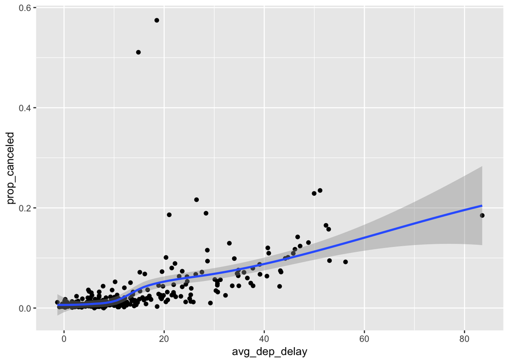

```r
canceled_delayed <-
  flights %>%
  mutate(canceled = (is.na(arr_delay) | is.na(dep_delay))) %>%
  group_by(year, month, day) %>%
  summarise(prop_canceled = mean(canceled),
            avg_dep_delay = mean(dep_delay, na.rm = TRUE))

ggplot(canceled_delayed, aes(x = avg_dep_delay, prop_canceled)) +
  geom_point() +
  geom_smooth()
```

# Question 5

### Frontier Airlines (F9) has the worst delays.

### You can get part of the way to disentangling the effects of airports vs. carriers by comparing each flight’s delay to the average delay of destination airport. However, you’d really want to compare it to the average delay of the destination airport, after removing other flights from the same airline.

```r
flights %>%
  group_by(carrier) %>%
  summarise(arr_delay = mean(arr_delay, na.rm = TRUE)) %>%
  arrange(desc(arr_delay))
```

```
## # A tibble: 16 x 2
##    carrier arr_delay
##    <chr>       <dbl>
##  1 F9         21.9
##  2 FL         20.1
##  3 EV         15.8
##  4 YV         15.6
##  5 OO         11.9
##  6 MQ         10.8
##  7 WN          9.65
##  8 B6          9.46
##  9 9E          7.38
## 10 UA          3.56
## 11 US          2.13
## 12 VX          1.76
## 13 DL          1.64
## 14 AA          0.364
## 15 HA         -6.92
## 16 AS         -9.93
```

# Question 6

### The sort argument to count() sorts the results in order of n. You could use this anytime you would run count() followed by arrange().

# 5.7.1

# Question 1

### instead of operating over the entire data frame, the filtering functions operate within each group when combined with grouping

# Question 2

### The are multiple planes that have nover been recorded as “on-time”, as shown in the table below:

```r
flights %>%
  filter(!is.na(arr_delay)) %>%
  mutate(canceled = is.na(arr_time),
         late = !canceled & arr_delay > 0) %>%
  group_by(tailnum) %>%
  summarise(on_time = mean(!late)) %>%
  filter(min_rank(on_time) <= 1)
```

```
## # A tibble: 104 x 2
##    tailnum on_time
##    <chr>     <dbl>
##  1 N121DE        0
##  2 N136DL        0
##  3 N143DA        0
##  4 N17627        0
##  5 N240AT        0
##  6 N26906        0
##  7 N295AT        0
##  8 N302AS        0
##  9 N303AS        0
## 10 N32626        0
## # ... with 94 more rows
```

# Question 3

### Based on the data and table shown, its filghts earlier in the day tend to have less delays than the later flights. It is best to take earlier flight to avoid delays.

```r
flights %>%
  group_by(hour) %>%
  summarise(arr_delay = mean(arr_delay, na.rm = TRUE)) %>%
  arrange(arr_delay)
```

```
## # A tibble: 20 x 2
##     hour arr_delay
##    <dbl>     <dbl>
##  1     7    -5.30
##  2     5    -4.80
##  3     6    -3.38
##  4     9    -1.45
##  5     8    -1.11
##  6    10     0.954
##  7    11     1.48
##  8    12     3.49
##  9    13     6.54
## 10    14     9.20
## 11    23    11.8
## 12    15    12.3
## 13    16    12.6
## 14    18    14.8
## 15    22    16.0
## 16    17    16.0
## 17    19    16.7
## 18    20    16.7
## 19    21    18.4
## 20     1   NaN
```

# Question 4

```r
flights %>%
  filter(!is.na(arr_delay), arr_delay > 0) %>%
  group_by(dest) %>%
  mutate(arr_delay_total = sum(arr_delay),
         arr_delay_prop = arr_delay / arr_delay_total)
```

```
## # A tibble: 133,004 x 21
## # Groups:   dest [103]
##     year month   day dep_time sched_dep_time dep_delay arr_time
##    <int> <int> <int>    <int>          <int>     <dbl>    <int>
##  1  2013     1     1      517            515         2      830
##  2  2013     1     1      533            529         4      850
##  3  2013     1     1      542            540         2      923
##  4  2013     1     1      554            558        -4      740
##  5  2013     1     1      555            600        -5      913
##  6  2013     1     1      558            600        -2      753
##  7  2013     1     1      558            600        -2      924
##  8  2013     1     1      559            600        -1      941
##  9  2013     1     1      600            600         0      837
## 10  2013     1     1      602            605        -3      821
## # ... with 132,994 more rows, and 14 more variables: sched_arr_time <int>,
## #   arr_delay <dbl>, carrier <chr>, flight <int>, tailnum <chr>,
## #   origin <chr>, dest <chr>, air_time <dbl>, distance <dbl>, hour <dbl>,
## #   minute <dbl>, time_hour <dttm>, arr_delay_total <dbl>,
## #   arr_delay_prop <dbl>
```

# Question 5

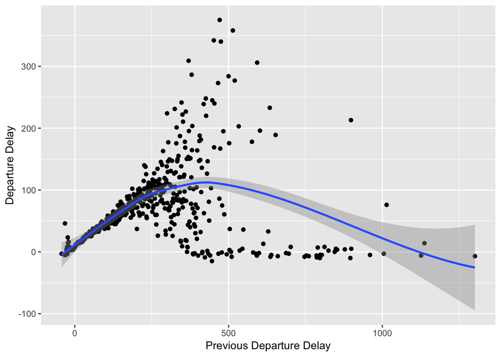

```r
### using lag() to explore how the delay of a flight is related to the delay of the immediately preceding flight

lagged_delays <- flights %>%
  arrange(origin, year, month, day, dep_time) %>%
  group_by(origin) %>%
  mutate(dep_delay_lag = lag(dep_delay)) %>%
  filter(!is.na(dep_delay), !is.na(dep_delay_lag))


lagged_delays %>%
  group_by(dep_delay_lag) %>%
  summarise(dep_delay_mean = mean(dep_delay)) %>%
  ggplot(aes(y = dep_delay_mean, x = dep_delay_lag)) +
  geom_point() +
  geom_smooth() +
  labs(y = "Departure Delay", x = "Previous Departure Delay")
```

```r
### summary of relationships in delays:

lagged_delays %>%
  summarise(delay_diff = mean(dep_delay - dep_delay_lag), na.rm = TRUE)
```

```
## # A tibble: 3 x 3
##   origin delay_diff na.rm
##   <chr>       <dbl> <lgl>
## 1 EWR        0.148  TRUE
## 2 JFK       -0.0319 TRUE
## 3 LGA        0.209  TRUE
```

# Question 6

```r
# super fast
not_cancelled %>% group_by(dest) %>%
    mutate(speed = distance / air_time) %>%
    arrange(-speed)
```

```
## # A tibble: 327,346 x 20
## # Groups:   dest [104]
##     year month   day dep_time sched_dep_time dep_delay arr_time
##    <int> <int> <int>    <int>          <int>     <dbl>    <int>
##  1  2013     5    25     1709           1700         9     1923
##  2  2013     7     2     1558           1513        45     1745
##  3  2013     5    13     2040           2025        15     2225
##  4  2013     3    23     1914           1910         4     2045
##  5  2013     1    12     1559           1600        -1     1849
##  6  2013    11    17      650            655        -5     1059
##  7  2013     2    21     2355           2358        -3      412
##  8  2013    11    17      759            800        -1     1212
##  9  2013    11    16     2003           1925        38       17
## 10  2013    11    16     2349           2359       -10      402
## # ... with 327,336 more rows, and 13 more variables: sched_arr_time <int>,
## #   arr_delay <dbl>, carrier <chr>, flight <int>, tailnum <chr>,
## #   origin <chr>, dest <chr>, air_time <dbl>, distance <dbl>, hour <dbl>,
## #   minute <dbl>, time_hour <dttm>, speed <dbl>
```

```r
# shortest flight per destination
not_cancelled %>% group_by(dest) %>%
    filter(air_time == min(air_time)) %>%
    select(dest, min_air = air_time) %>%
    inner_join(flights, by = "dest") %>%
    mutate(relative_air = air_time / min_air) %>%
    arrange(-relative_air)
```

```
## # A tibble: 549,643 x 21
## # Groups:   dest [104]
##    dest  min_air  year month   day dep_time sched_dep_time dep_delay
##    <chr>   <dbl> <int> <int> <int>    <int>          <int>     <dbl>
##  1 BOS        21  2013     6    24     1932           1920        12
##  2 BOS        21  2013     6    17     1652           1700        -8
##  3 BOS        21  2013     7    23     1605           1400       125
##  4 BOS        21  2013     7    23     1617           1605        12
##  5 BOS        21  2013     7    23     1242           1237         5
##  6 BOS        21  2013     7    23     1200           1200         0
##  7 BOS        21  2013     2    17      841            840         1
##  8 BOS        21  2013     7    23     1242           1245        -3
##  9 DCA        32  2013     6    10     1356           1300        56
## 10 DCA        32  2013     6    10     1356           1300        56
## # ... with 549,633 more rows, and 13 more variables: arr_time <int>,
## #   sched_arr_time <int>, arr_delay <dbl>, carrier <chr>, flight <int>,
## #   tailnum <chr>, origin <chr>, air_time <dbl>, distance <dbl>,
## #   hour <dbl>, minute <dbl>, time_hour <dttm>, relative_air <dbl>
```

# Question 7

### ExpressJet Airlines flies to at least 2 carriers and flies to the most destinations.

```r
dest_2carriers <- flights %>%
  # keep only unique carrier,dest pairs
  select(dest, carrier) %>%
  group_by(dest, carrier) %>%
  filter(row_number() == 1) %>%
  # count carriers by destination
  group_by(dest) %>%
  mutate(n_carrier = n_distinct(carrier)) %>%
  filter(n_carrier >= 2)

carriers_by_dest <- dest_2carriers %>%
  group_by(carrier) %>%
  summarise(n_dest = n()) %>%
  arrange(desc(n_dest))
head(carriers_by_dest)
```

```
## # A tibble: 6 x 2
##   carrier n_dest
##   <chr>    <int>
## 1 EV          51
## 2 9E          48
## 3 UA          42
## 4 DL          39
## 5 B6          35
## 6 AA          19
```

# Question 8

```r
flights %>%
  arrange(tailnum, year, month, day) %>%
  group_by(tailnum) %>%
  mutate(delay_gt1hr = dep_delay > 60) %>%
  mutate(before_delay = cumsum(delay_gt1hr)) %>%
  filter(before_delay < 1) %>%
  count(sort = TRUE)
```

```
## # A tibble: 3,755 x 2
## # Groups:   tailnum [3,755]
##    tailnum     n
##    <chr>   <int>
##  1 N954UW    206
##  2 N952UW    163
##  3 N957UW    142
##  4 N5FAAA    117
##  5 N38727     99
##  6 N3742C     98
##  7 N5EWAA     98
##  8 N705TW     97
##  9 N765US     97
## 10 N635JB     94
## # ... with 3,745 more rows
```

# Chapter 7

# 7.3.4

# Question 1

### The x an y distributions are essentialy the same. It appears that large diamonds are found in less quanitity than smaller diamonds. Also, all three distributions have a bimodality, or two noticable peas in their data representation.

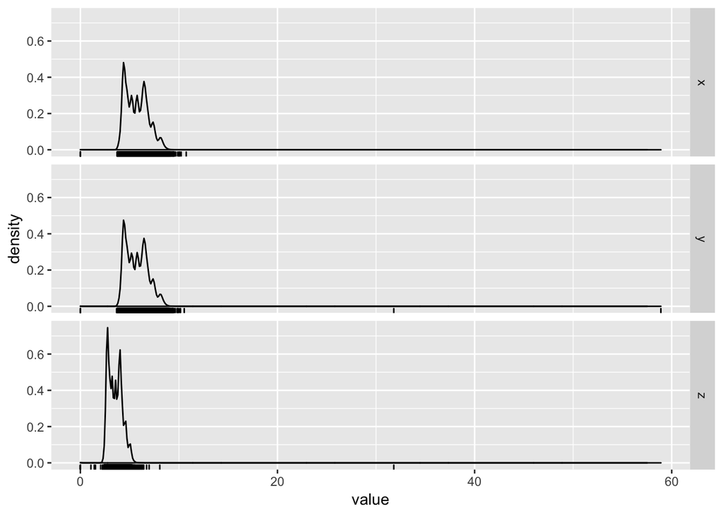

```r
diamonds %>%
  mutate(id = row_number()) %>%
  select(x, y, z, id) %>%
  gather(variable, value, -id)  %>%
  ggplot(aes(x = value)) +
  geom_density() +
  geom_rug() +
  facet_grid(variable ~ .)
```

# Question 2

### There are diamonds available with prices ranging from $1000 to $2000 on this graph, however there are no diamonds priceds around $1500 for this particular data.

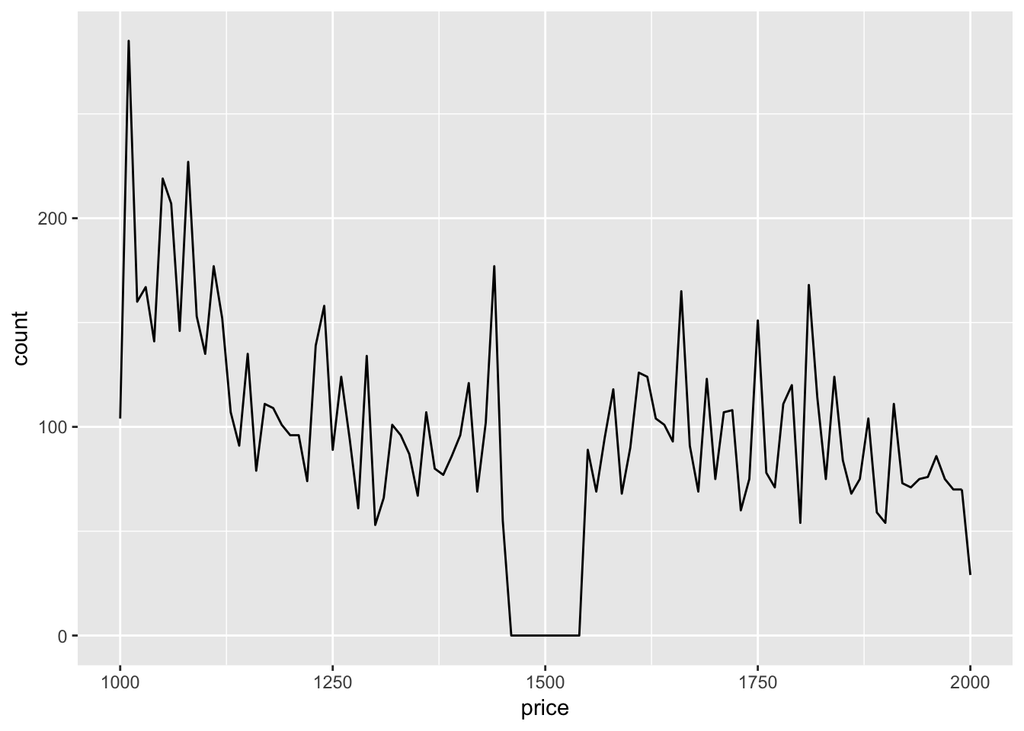

```r
diamonds <- diamonds %>% filter(2 < y & y < 20 & 2 < x & 2 < z & z < 20)
ggplot(diamonds) +
  geom_freqpoly(aes(x = price), binwidth = 10) +
  xlim(c(1000, 2000))
```

# Question 3

### There seems to be alot more diamonds of 1 carat and not as many 0.99 carrat. 1 is a more whole number than 0.99. Just like in grocery stores where items are mostly priced as $X.99 can have a pyschological effect on consumers, a 1 carat diamond may sound alot more enticing that 0.99 carat and therefore there are more 1 carat diamonds.

```r
diamonds %>% filter(carat == 0.99) %>% count()
```

```
## # A tibble: 1 x 1
##       n
##   <int>
## 1    23
```

```r
diamonds %>% filter(carat == 1) %>% count()
```

```
## # A tibble: 1 x 1
##       n
##   <int>
## 1  1556
```

# Question 4

### coord_cartesian() plots and cuts, while xlim() cuts and plots. So xlim() does not show the half bar.

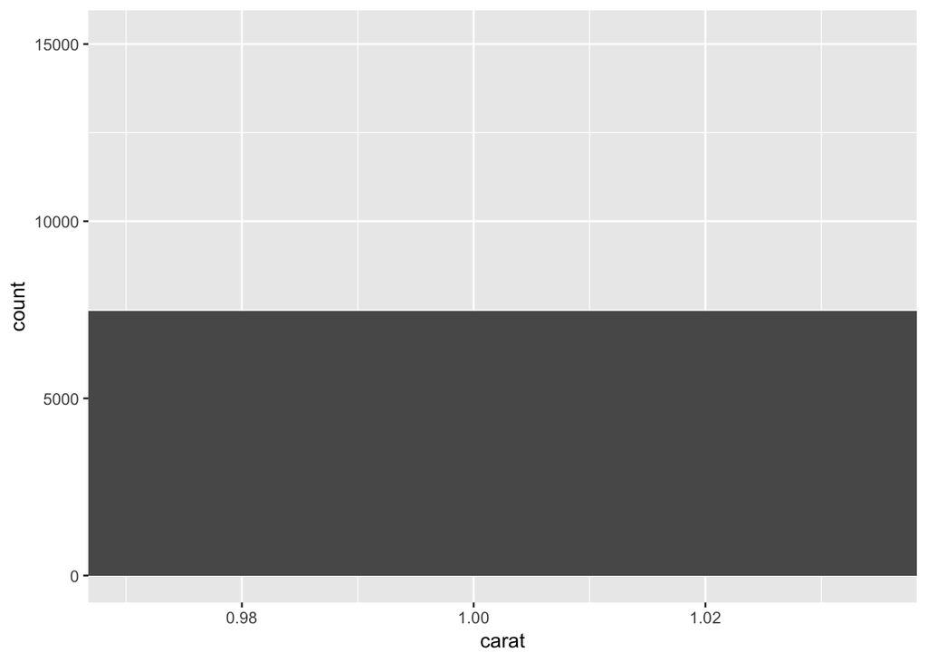

```r
ggplot(diamonds) +
  geom_histogram(aes(x = carat)) +
  coord_cartesian(xlim = c(0.97, 1.035))
```

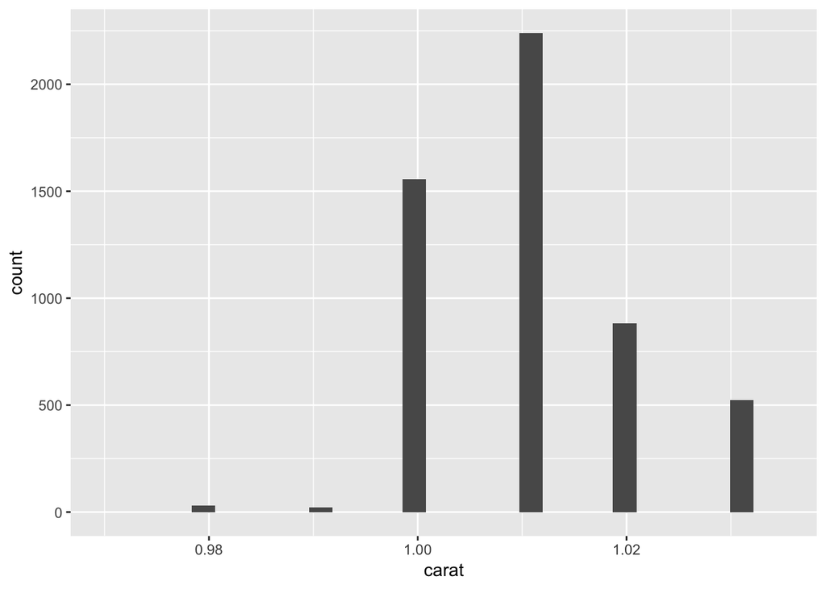

```r
ggplot(diamonds) +
  geom_histogram(aes(x = carat)) +
  xlim(c(0.97, 1.035))
```

# 7.4.1

# Question 1

### In a histogram, they simply leave a gap in the distribution, as in the gap in the above histogram of price. For the barplot, the function removes the NA value.

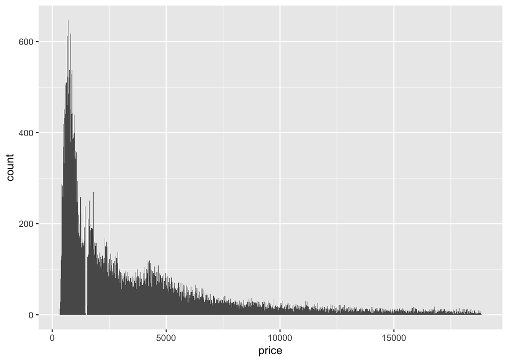

```r
diamonds %>%
  ggplot(aes(price)) +
  geom_histogram(bins = 1000)
```

# Question 2

### na.rm ignores the “NA”s when calculating mean and sum.

# 7.5.1.1

# Question 1

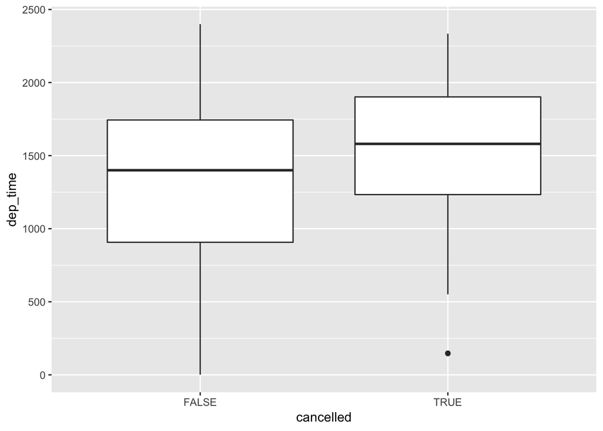

```r
flights %>%
  mutate(cancelled = is.na(dep_time) | is.na(arr_time)) %>%
  ggplot() +
  geom_boxplot(aes(x = cancelled, y = dep_time))
```

```r
flights %>%
  mutate(cancelled = is.na(dep_time) | is.na(arr_time)) %>%
  filter(cancelled) %>%
  select(dep_time)
```

```
## # A tibble: 8,713 x 1
##    dep_time
##       <int>
##  1     2016
##  2       NA
##  3       NA
##  4       NA
##  5       NA
##  6     2041
##  7     2145
##  8       NA
##  9       NA
## 10       NA
## # ... with 8,703 more rows
```

# Question 2

### Carat seems to be the most important variable when predicting the price of a diamond, therefore it is the most important variable. Carat and cut seem to have a negative correlation, indicating that higher weighted diamonds usually have a lower cut rating. Lower quality diamonds end up being more expensive because better cut has lower carat, which makes the price lower.

```r
diamonds %>%
  mutate(cut = as.numeric(cut),
         color = as.numeric(color),
         clarity = as.numeric(clarity)) %>%
  select(price, everything()) %>%
  cor()
```

```
##               price       carat         cut       color     clarity
## price    1.00000000  0.92158063 -0.05355875  0.17235219 -0.14674223
## carat    0.92158063  1.00000000 -0.13503751  0.29128905 -0.35272284
## cut     -0.05355875 -0.13503751  1.00000000 -0.02055151  0.18917970
## color    0.17235219  0.29128905 -0.02055151  1.00000000  0.02582832
## clarity -0.14674223 -0.35272284  0.18917970  0.02582832  1.00000000
## depth   -0.01062829  0.02838113 -0.21806310  0.04741234 -0.06750955
## table    0.12730523  0.18172046 -0.43330144  0.02649588 -0.16026257
## x        0.88721334  0.97777660 -0.12631841  0.27060157 -0.37283865
## y        0.88881050  0.97685840 -0.12594758  0.27040958 -0.36750088
## z        0.88257455  0.97699136 -0.15234197  0.27511931 -0.37657327
##               depth       table           x           y           z
## price   -0.01062829  0.12730523  0.88721334  0.88881050  0.88257455
## carat    0.02838113  0.18172046  0.97777660  0.97685840  0.97699136
## cut     -0.21806310 -0.43330144 -0.12631841 -0.12594758 -0.15234197
## color    0.04741234  0.02649588  0.27060157  0.27040958  0.27511931
## clarity -0.06750955 -0.16026257 -0.37283865 -0.36750088 -0.37657327
## depth    1.00000000 -0.29577797 -0.02491377 -0.02804909  0.09667993
## table   -0.29577797  1.00000000  0.19617416  0.19002073  0.15581798
## x       -0.02491377  0.19617416  1.00000000  0.99865733  0.99161896
## y       -0.02804909  0.19002073  0.99865733  1.00000000  0.99127624
## z        0.09667993  0.15581798  0.99161896  0.99127624  1.00000000
```

# Question 3

### Seems like the result is the same; but the call of the function seems more natural.

# Question 4

### While the boxplot only shows a few quantiles and outliers, the letter-value plot shows many quantiles.

# Question 5

### Violin plot is best to compare the density distribution across different categories.

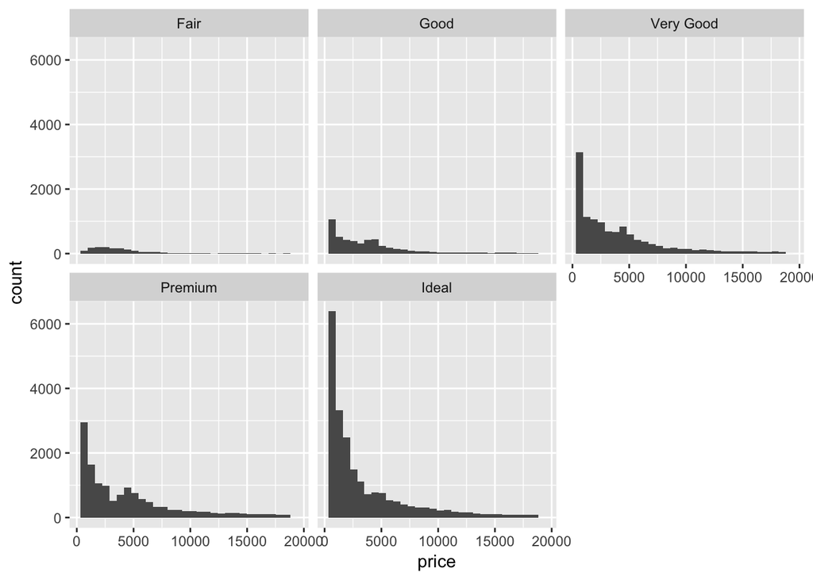

```r
ggplot(diamonds) +
  geom_histogram(aes(x = price)) +
  facet_wrap(~cut)
```

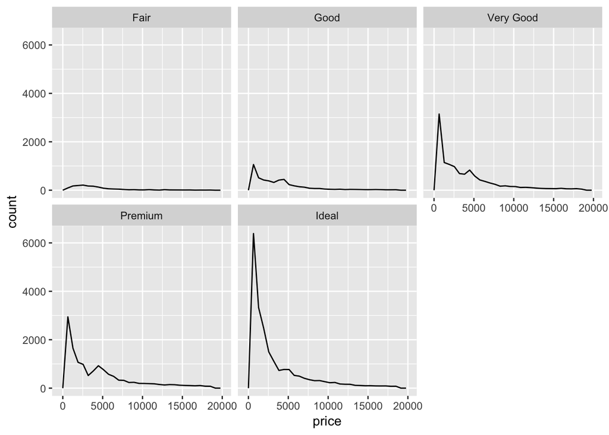

```r
ggplot(diamonds) +
  geom_freqpoly(aes(x = price)) +
  facet_wrap(~cut)
```

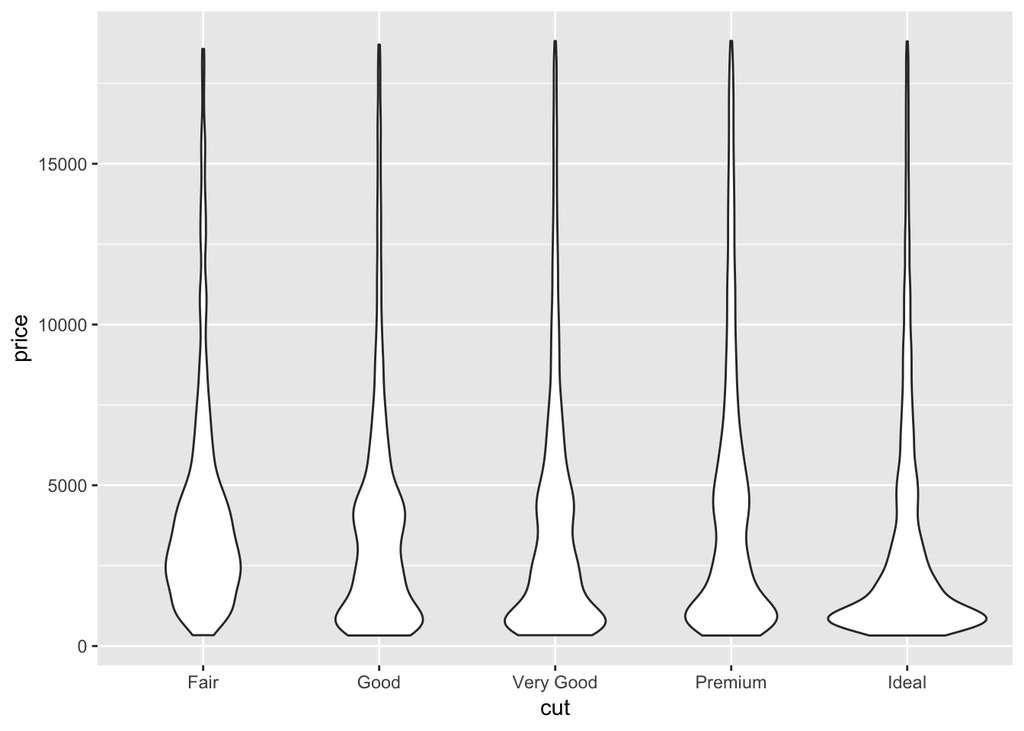

```r
ggplot(diamonds) +
  geom_violin(aes(x = cut, y = price))
```

# Question 6

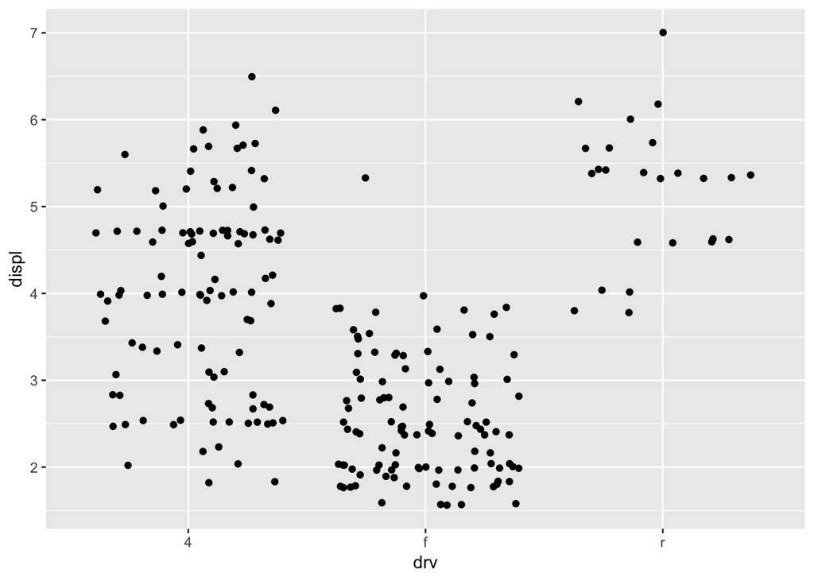

```r
ggplot(data = mpg) +
  geom_jitter(mapping = aes(x = drv, y = displ))
```

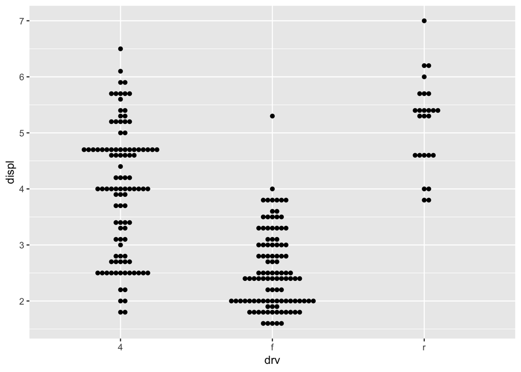

```r
library(ggbeeswarm)
ggplot(data = mpg) +
  geom_beeswarm(mapping = aes(x = drv, y = displ), priority = 'ascending')
```

# 7.5.2.1

# Question 1

### We can calculate the proportion of each cut within color, and vice versa.

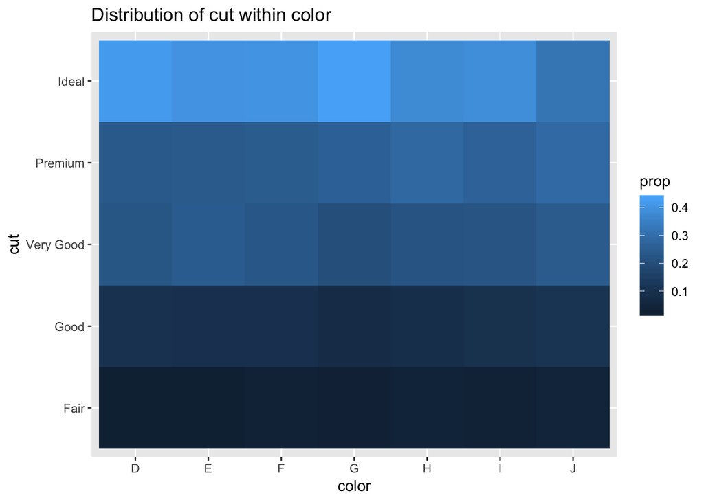

```r
diamonds %>% count(color, cut) %>% group_by(color) %>%
  mutate(prop = n / sum(n)) %>%
  ggplot() +
  geom_tile(mapping = aes(x = color, y = cut, fill = prop)) +
  labs(title = 'Distribution of cut within color')
```

# Question 2

### The plot is not easy to read because:

### 1. the color scale range makes it hard to distinguish and compare airports and months

### 2. there are empty cells, which denote missing values (no flights departed from the airport, different from averaged delayed in 0 minutes)

### 3. the x label is incorrect

### We will keep the NA cells for two reasons:

### 1. not ideal if we remove the entire row. The non-missing cells still represent data.

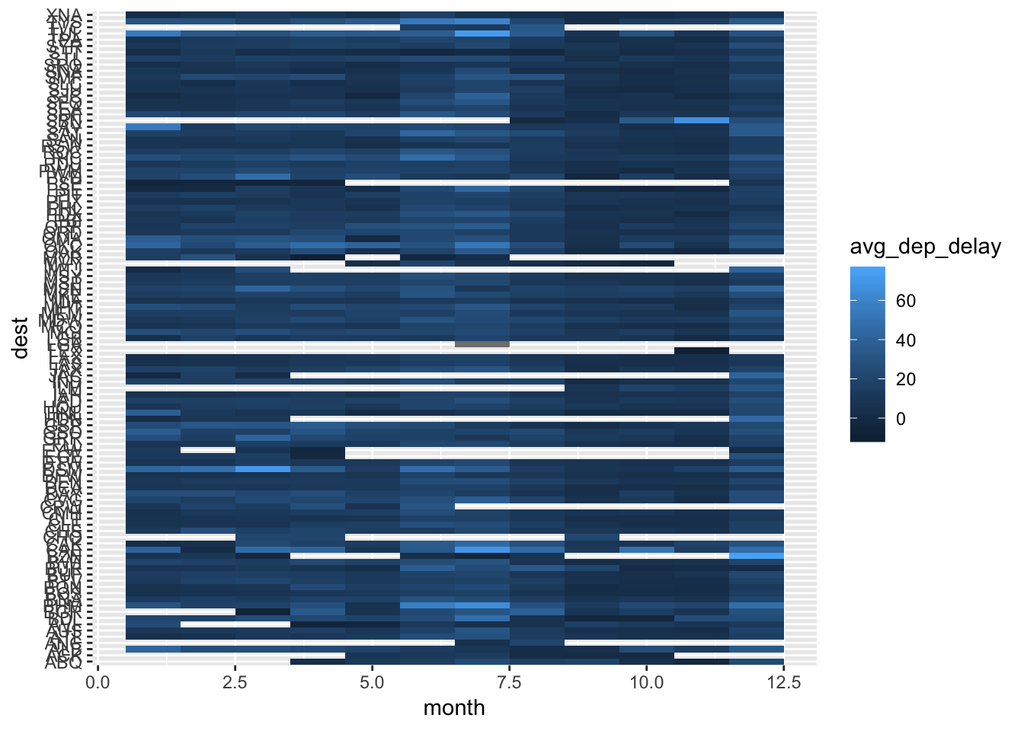

```r
nycflights13::flights %>% group_by(dest, month) %>%
  summarize(avg_dep_delay = mean(dep_delay, na.rm = TRUE)) %>%
  ggplot() +
  geom_tile(mapping = aes(x = month, y = dest, fill = avg_dep_delay))
```

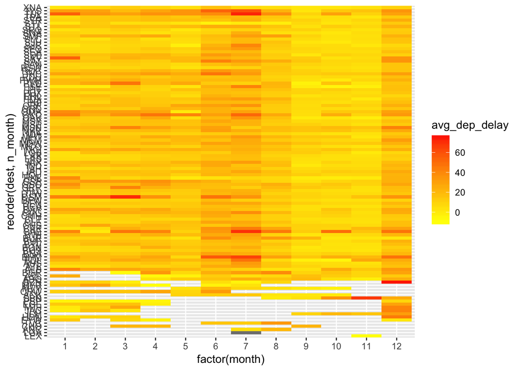

```r
nycflights13::flights %>% group_by(dest, month) %>%
  summarize(avg_dep_delay = mean(dep_delay, na.rm = TRUE)) %>%
  ungroup() %>%
  group_by(dest) %>%
  mutate(n_month = n())%>%
  ggplot() +
  geom_tile(mapping = aes(x = factor(month),
                          y = reorder(dest, n_month),
                          fill = avg_dep_delay)) +
  scale_fill_gradient2(low = 'yellow', mid = 'orange', high = 'red',
                       midpoint = 35)
```

# Question 3

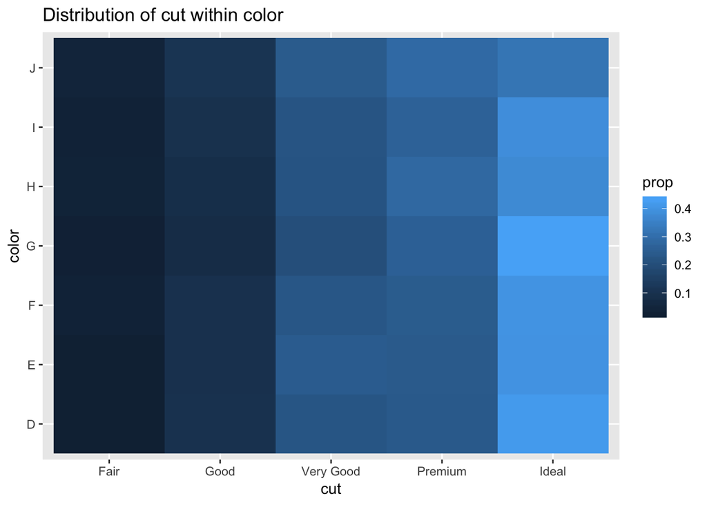

```r
diamonds %>% count(color, cut) %>% group_by(color) %>%
  mutate(prop = n / sum(n)) %>%
  ggplot() +
  geom_tile(mapping = aes(x = cut, y = color, fill = prop)) +
  labs(title = 'Distribution of cut within color')
```

7.5.3.1

# Question 1

### Unlike geom_density(), geom_freqpoly() is a smoothered histogram, so the height of each polygon is affected by the number of observations in each group. Setting the cut_width too small will have too many categories. Some of the categories will have very few observations, resulting in polygons that are flat and close to the x-axis. Compare the cut_width of .2 and .4:

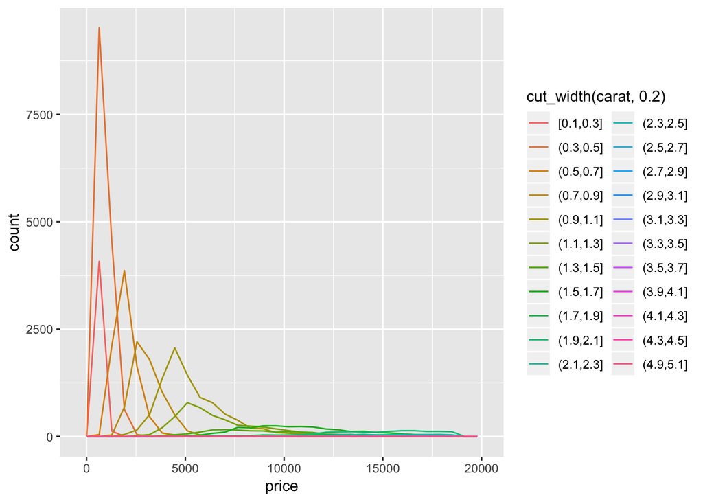

```r
diamonds %>% ggplot() +
  geom_freqpoly(mapping = aes(x = price,
                              color = cut_width(carat, .2)), bins = 30)
```

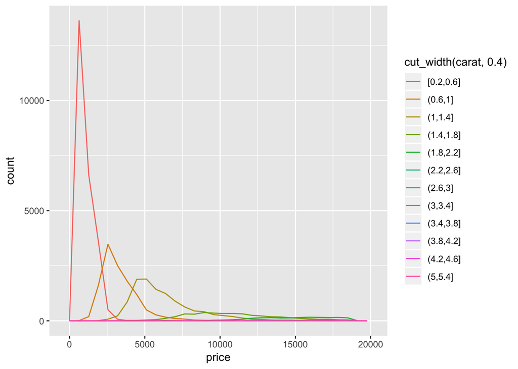

```r
diamonds %>% ggplot() +
  geom_freqpoly(mapping = aes(x = price,
                              color = cut_width(carat, .4)), bins = 30)
```

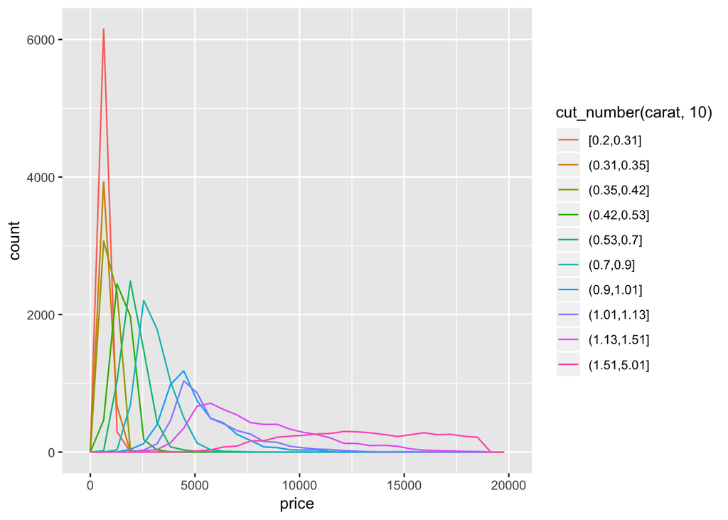

```r
diamonds %>% ggplot() +
  geom_freqpoly(mapping = aes(x = price,
                              color = cut_number(carat, 10)), bins = 30)
```

# Question 2

### Using geom_density() and partitioning by price with cut_width, it is not surprising to see that diamonds of higher carat are associated with higher price in general.

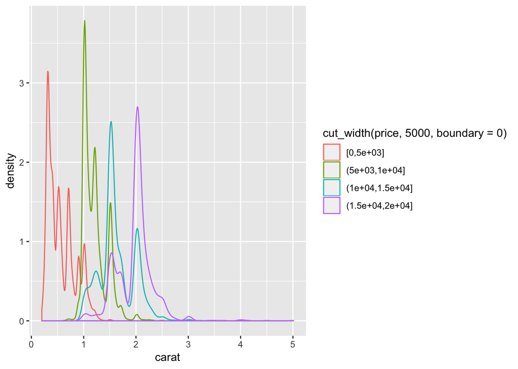

```r
diamonds %>% ggplot() +
  geom_density(mapping = aes(x = carat,
                             color = cut_width(price, 5000, boundary = 0)))
```

# Question 3

### The price distribution of very large diamonds are much more variable than the smaller diamonds. Perhaps other factors, such as cut, clarity, and color have heavier influence on the price of larger diamonds.

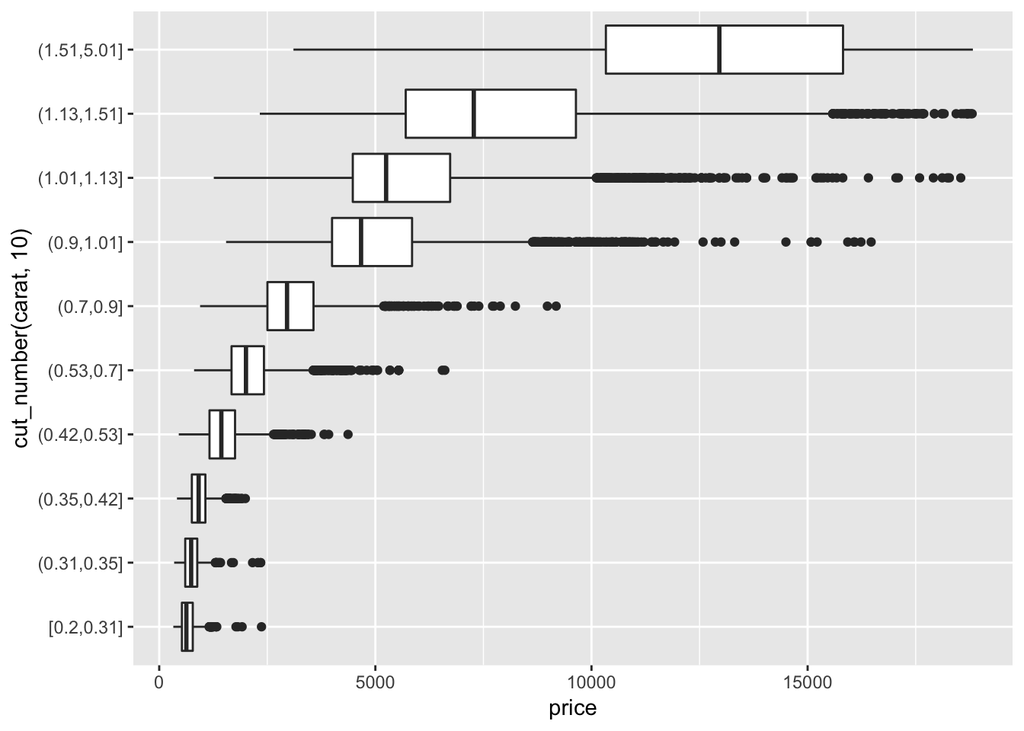

```r
diamonds %>% ggplot +
  geom_boxplot(mapping = aes(x = cut_number(carat, 10),
                             y = price)) +
  coord_flip()
```

# Question 4

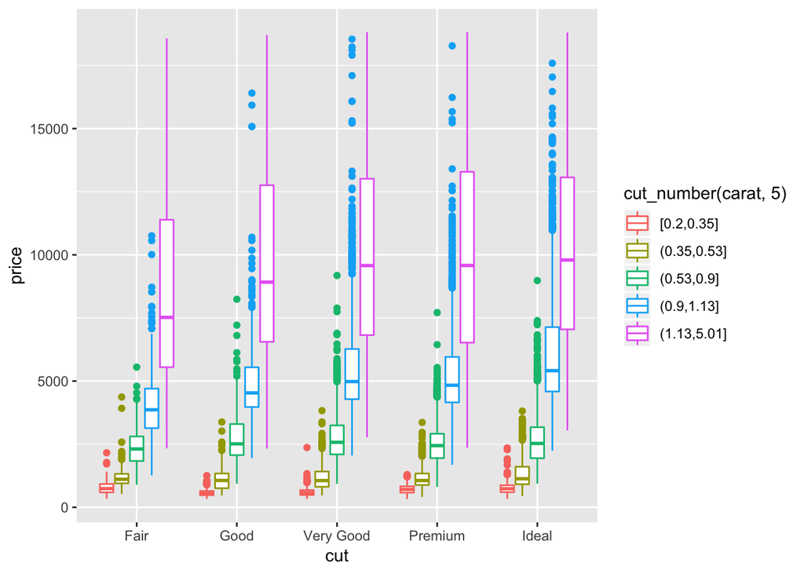

```r
  diamonds %>% ggplot() +
  geom_boxplot(mapping = aes(x = cut, y = price,
                             color = cut_number(carat, 5)))
```

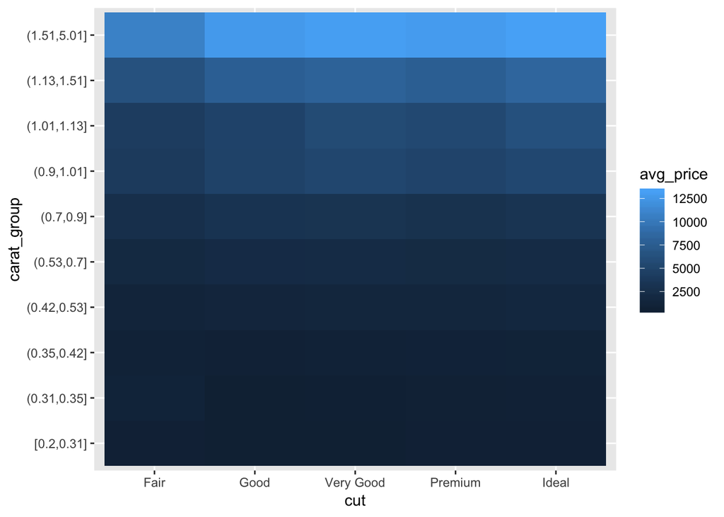

```r
diamonds %>% mutate(carat_group = cut_number(carat, 10)) %>%
  group_by(cut, carat_group) %>%
  summarize(avg_price = mean(price)) %>%
  ggplot() +
  geom_tile(mapping = aes(x = cut, y = carat_group,
                          fill = avg_price))
```

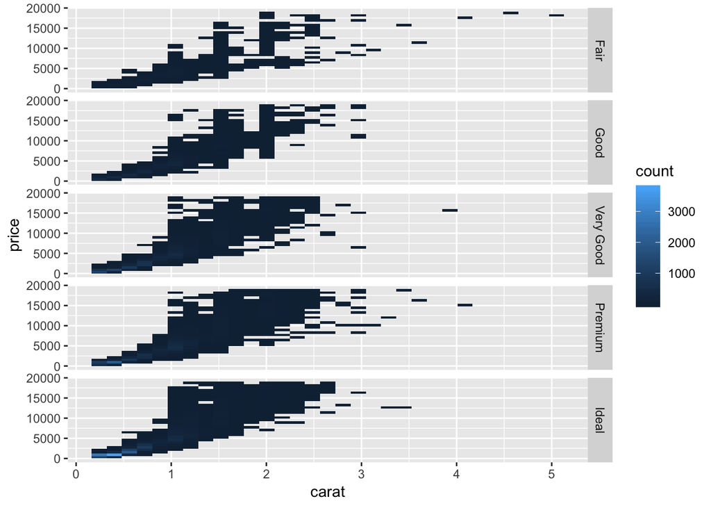

```r
diamonds %>% ggplot() +
  geom_bin2d(mapping = aes(x = carat, y = price)) +
  facet_grid(cut~.)
```

# Question 5

### In the first scatterplot, we can identity the outliers while at the same time observe the strong positive correlation between x and y.

### Even though they look similarly, I believe the logical reasoning behind why scatterplot is superior in this case is that it focuses on showing the locations of each individual point, rather than the binned counts, thus it’s more suitable for the purpose of identifying outliers.

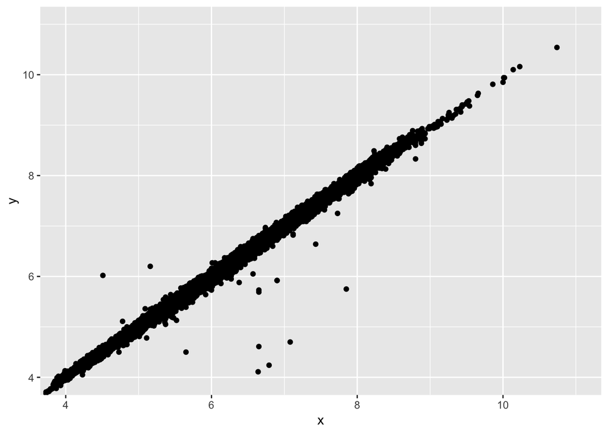

```r
ggplot(data = diamonds) +
  geom_point(mapping = aes(x = x, y = y)) +
  coord_cartesian(xlim = c(4, 11), ylim = c(4, 11))
```

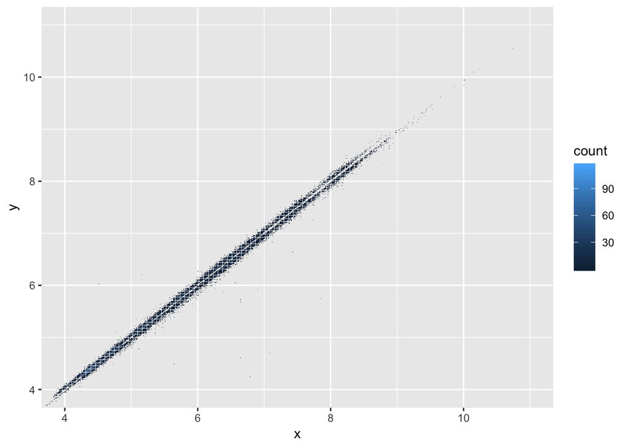

```r
ggplot(data = diamonds) +
  geom_bin2d(mapping = aes(x = x, y = y), bins = 800) +
  coord_cartesian(xlim = c(4, 11), ylim = c(4, 11))
```